# NCD-RisC Data Analysis: Diabetes and Obesity Trends

Nepoliyan Ria, Hamsini Arakere Manjunath, Sancha Baretto, Rajbala Mohan Jadhav

2025-11-10

# 1 Introduction

This report investigates trends in diabetes and obesity prevalence using NCD-RisC data, following two cycles of the CRISP-DM methodology. The first cycle explores temporal trends in selected countries, while the second cycle examines the relationship between obesity and diabetes prevalence. All visualizations are interactive - hover over data points for details!

# 2 CRISP-DM Cycle 1: Temporal Trends Analysis

## 2.1 Business Understanding

**Research Question:** How has diabetes prevalence changed over time in high-income countries, and are there differences between men and women?

**Objectives:**

- Identify temporal trends in diabetes prevalence
- Compare trends across selected countries
- Examine sex differences in diabetes prevalence

## 2.2 Data Understanding

```
## Diabetes dataset dimensions: 13200 11
```

```
## BMI dataset dimensions: 13200 34
```

```
## Year range (diabetes): 1990 2022
```

```
## Number of countries: 200
```

The diabetes dataset contains 13200 observations across 200 countries/regions, covering years 1990 to 2022.

## 2.3 Data Preparation

Data cleaning was performed in the munge script (`01-clean-data.R`):

- Renamed columns for easier handling
- Removed rows with missing key variables
- Ensured year values are numeric
- Filtered for relevant sex categories

For this analysis, we focus on four high-income countries: United Kingdom, United States, Germany, and Japan.

## 2.4 Modeling / Analysis

### 2.4.1 Diabetes Trends Over Time

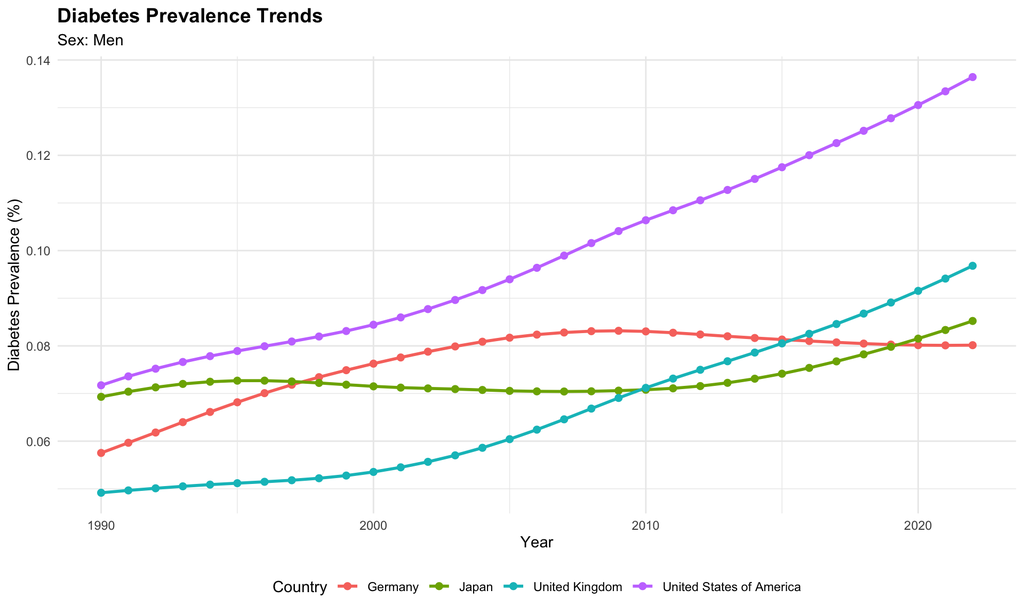

Diabetes prevalence trends in selected countries (Interactive)

### 2.4.2 Sex Differences in Diabetes

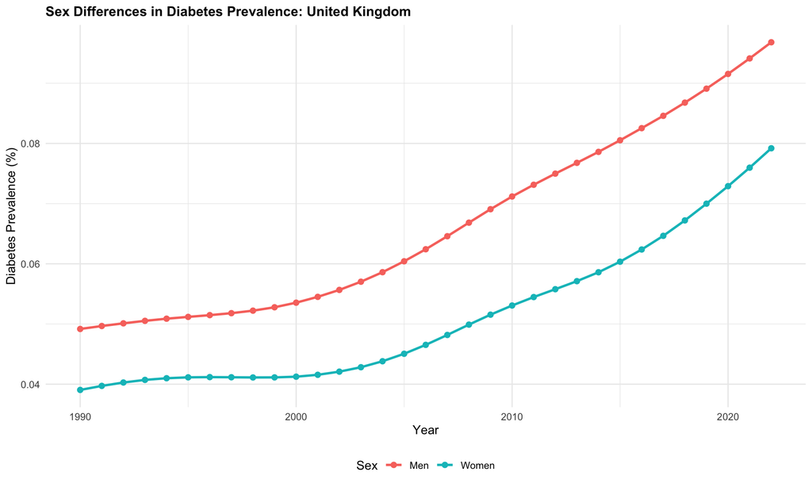

Sex differences in diabetes prevalence - UK (Interactive)

In the United Kingdom, men consistently show higher diabetes prevalence than women throughout the time period.

## 2.5 Evaluation

Summary statistics for selected countries (Men)

| country | years_available | year_range | mean_diabetes | latest_diabetes | mean_obesity | latest_obesity | diabetes_change |
| --- | --- | --- | --- | --- | --- | --- | --- |
| United Kingdom | 33 | 1990 - 2022 | 0.07 | 0.10 | 0.21 | 0.27 | 0.05 |
| United States of America | 33 | 1990 - 2022 | 0.10 | 0.14 | 0.31 | 0.42 | 0.06 |
| Germany | 33 | 1990 - 2022 | 0.08 | 0.08 | 0.20 | 0.23 | 0.02 |
| Japan | 33 | 1990 - 2022 | 0.07 | 0.09 | 0.04 | 0.08 | 0.02 |

**Observations:**

- All four countries show increasing diabetes prevalence over time
- The United States has the highest diabetes prevalence among countries analyzed.
- Men generally have higher diabetes rates than women
- The rate of increase varies by country

# 3 CRISP-DM Cycle 2: Obesity-Diabetes Relationship

## 3.1 Business Understanding

**Research Question:** Is there a relationship between obesity prevalence and diabetes prevalence at the country level?

**Objectives:**

- Examine correlation between obesity and diabetes
- Identify countries with high rates of both conditions
- Explore whether the relationship has changed over time

**Hypothesis:** Countries with higher obesity rates will have higher diabetes rates, as obesity is a known risk factor for Type 2 diabetes.

## 3.2 Data Understanding

For this cycle, we use the combined dataset that includes both diabetes and obesity prevalence:

The combined dataset was created in the munge script by inner joining diabetes and BMI datasets on country, ISO code, sex, and year. Only observations where both diabetes and obesity data are available were retained.

## 3.4 Modeling / Analysis

### 3.4.1 Overall Correlation

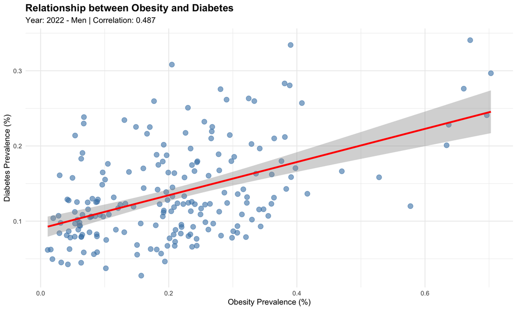

Relationship between obesity and diabetes (Interactive)

### 3.4.2 Countries with Highest Prevalence

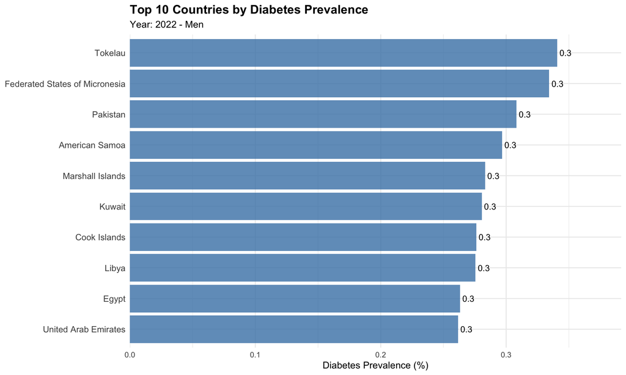

Top 10 countries by diabetes prevalence (Interactive)

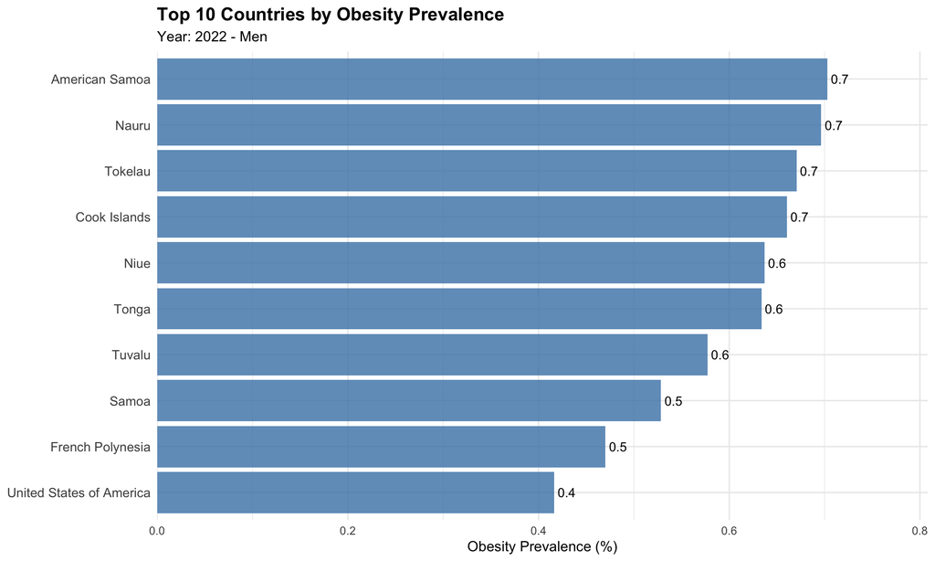

Top 10 countries by obesity prevalence (Interactive)

### 3.4.3 Obesity Trends in Selected Countries

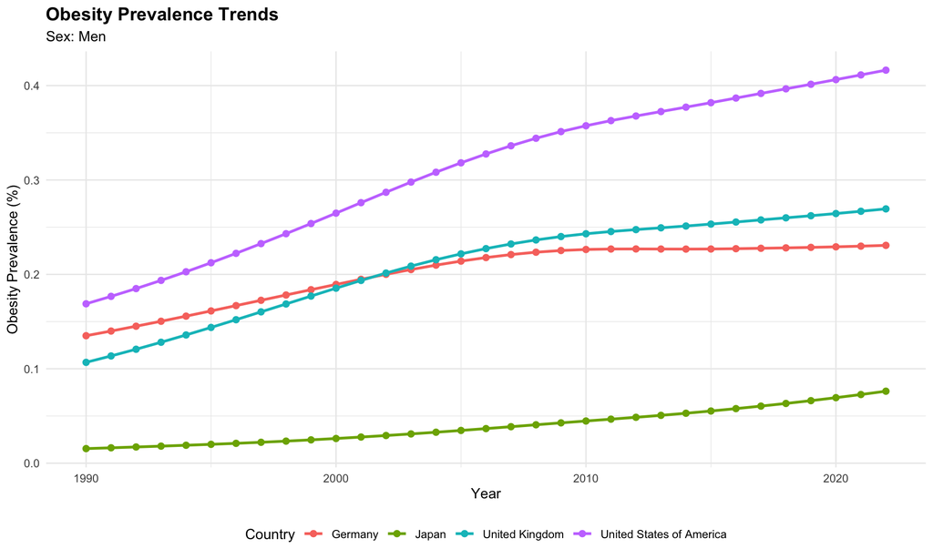

Obesity prevalence trends (Interactive)

Both diabetes and obesity show increasing trends, with obesity rates rising more steeply in some countries.

## 3.5 Evaluation

# 4 Interactive Global Visualizations

## 4.1 Global Diabetes Prevalence Map

[interactive chart not shown]

## 4.2 Global Treatment Rates Map

[interactive chart not shown]

**Key Observations:** Treatment rates vary significantly between countries. Some countries with high diabetes prevalence have low treatment rates, indicating a treatment gap. For instance, many countries in Africa and in Asia such Kenya have diabetes prevalence but low treatment rates

## 4.3 Treatment vs Prevalence Scatter Plot

[interactive chart not shown]

**Interpretation:** Each point represents a country. Countries in the upper right have both high prevalence and high treatment rates. Countries in the lower right have high prevalence but low treatment coverage.

## 4.4 Global Obesity Prevalence Map

[interactive chart not shown]

**Comparison:** If we compare this map with the diabetes map above we can notice the similar geographical patterns in many regions.

# 5 Overall Conclusions

This analysis employed two CRISP-DM cycles to investigate NCD-RisC data:

**Cycle 1** revealed increasing diabetes trends across high-income countries with sex differences favoring higher rates in men.

**Global Patterns:**

- Diabetes and obesity prevalence are increasing globally
- Significant geographical variation exists in both conditions
- Treatment coverage varies dramatically between countries
- Men show higher diabetes rates than women in most countries

# 6 Appendix: Technical Details

## 6.1 Data Sources

Data obtained from the NCD Risk Factor Collaboration (NCD-RisC):

- Diabetes prevalence estimates (18+ years)
- BMI/obesity prevalence estimates
- Available at: http://ncdrisc.org/

## 6.2 Statistical Methods

- **Correlation analysis:** Pearson correlation coefficient
- **Visualization:** ggplot2 and plotly for maps
- **Data manipulation:** dplyr package
- All analysis conducted in R version R version 4.5.2 (2025-10-31)